# Anonymisation - CESSDA TRAINING

[Consortium of European Social Science Data Archives](https://www.cessda.eu/)

## Anonymisation

> I am collecting data on asylum seekers' and refugees' experiences of forced labour. These participants can be considered 'doubly vulnerable'. We want to share these data. How should we protect our participant's anonymity?

##### A possible approach

The best way to protect your participant's privacy may be not to collect certain identifiable information at all. The second best is anonymisation which allows data to be shared whilst protecting participant’s personal information. Anonymisation should be considered in the context of the whole project and how it can be utilised alongside, informed consent and access controls. For example, if a participant consents to their data being shared then the use of anonymisation may not be required.

Personal data can be disclosed through two categories of identifiers.

- **Direct identifiers** are ones like the participant’s name, address, or telephone numbers that specifically identify them;
- **Indirect identifiers** are ones that when they are placed with other information could also reveal an individual, for example, by cross-referencing occupation, salary, age, and location.

[figure not shown]

### Anonymisation methods

**Quantitative data**

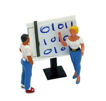

**The best practices for anonymising quantitative data**

- This may involve removing or aggregating variables or reducing the precision or detailed textual meaning of a variable;
- Aggregate or reduce the precision of a variable such as age or place of residence. As a general rule, report the lowest level of geo-referencing that will not potentially breach respondent confidentiality;
- Generalise the meaning of a detailed text variable by replacing potentially disclosive free-text responses with more general text;
- Restrict the upper or lower ranges of a continuous variable to hide outliers if the values for certain individuals are unusual or atypical within the wider group researched.

### Expert tips

[figure not shown]

- **1. Data access controls**  
  In situations where (sensitive) personal data are not fully anonymised, data can still be archived and shared by regulating or limiting access to the data. Access controls can permit control down to an individual file level, meaning that mixed levels of access control can be applied to a data collection. You will learn more about choosing the appropriate data access category for your data files in the chapter on archiving and publishing data (see '[Access categories](https://www.cessda.eu/Training/Training-Resources/Library/Data-Management-Expert-Guide/6.-Archive-Publish/Publishing-with-CESSDA-archives/Access-categories)').

  **2. Irreversible anonymisation**  
  In some countries, anonymisation needs to be irreversible and the original data deleted. Be sure to check the national requirements.

  **3. Anonymisation tools**  
  The UK Data Archive (n.d.b.) has developed a [Text anonymisation helper tool](http://data-archive.ac.uk/media/504356/md5_94fc0c2a25f3a75396059826a23b8224_textanonymisationhelpertool_01_00.zip) (downloads in a .zip file) with [how to install instructions](https://bitbucket.org/ukda/ukds.tools.textanonhelper/wiki/Home) via Wiki. It is an add-on MS Word macro for aiding anonymisation of qualitative data.

  **4. Reading tip**  
  In [this factsheet by OpenAIRE](https://www.cessda.eu/content/download/3846/35043/file/personal_data_factsheet_updated_April17.pdf) (2017) you are guided in how to balance open access and data protection and advised on what to do when anonymisation isn't possible.

### Case study

In [a research study](https://discover.ukdataservice.ac.uk/catalogue/?sn=7657&type=Data%20catalogue) on investigating how couples manage their households during recessions (Gush and Laury, 2015), finding the right balance between confidentiality and usefulness of the data [was a real challenge](https://www.ukdataservice.ac.uk/deposit-data/stories/gush) (UK Data Service, 2017c). Archiving challenges with this project were to anonymise the data and apply optimal access conditions.

Careful judgement was required to apply the level of anonymisation most appropriate for this particular data. The research team members went through the transcripts and removed certain types of identifying data such as names, places of work, and geographic areas. Regarding access conditions, it was decided to make the data available using a [Special Licence](https://www.ukdataservice.ac.uk/get-data/how-to-access/conditions/special-licence) (UK Data Service, 2017d; see '[Licensing your data](https://www.cessda.eu/Training/Training-Resources/Library/Data-Management-Expert-Guide/6.-Archive-Publish/Publishing-with-CESSDA-archives/Licensing-your-data)' for other possible licences). Under this kind of licence, a potential user is required not only to register with the UK Data Service, but also to complete a detailed application form and agree to additional restrictions on data handling and usage. The use of the Special Licence then made it possible to apply a minimal level of anonymisation, thus reducing the loss of data quality.

### A practice in anonymising qualitative data

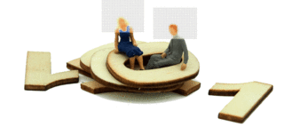